# Ripple Effect Monthly Report

Caitlin Mook and Ellie Rotheray

07 September 2025

[figure not shown]

Ripple Effect is working with local volunteers to monitor water quality and pollution across 13–15 sites along three, 10km stretches of the Upper River Medway, including the Grom and Eridge Stream. You can explore all our monitoring locations and data on our [interactive map](https://project-ripple-effect.co.uk/map) - just click on a site and scroll to see what we’ve found.

Each month, our citizen scientists test for key indicators of water health: ammonia, phosphate, conductivity, and temperature. We aim for surveys to be carried out on the same Monday between 10am and 2pm, helping us capture consistent data and spot pollution incidents.

We also use the [Riverfly](https://www.riverflies.org/) method to assess ecological health. Volunteers carry out a “kick sample” in the riverbed, identifying and counting eight groups of freshwater invertebrates. These creatures vary in their tolerance to pollution, so their presence or absence helps us calculate a water quality score.

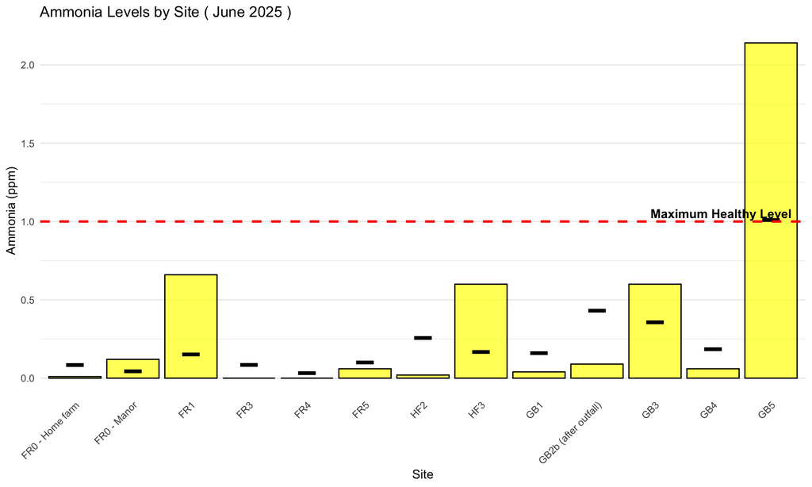

This figure shows the ammonia concentration (ppm) recorded at each monitoring site this month.

- The red dashed line marks the maximum healthy threshold. Levels above this may indicate pollution.
- The black dashed lines show the historical average for each site, helping to identify unusual spikes.

To interpret the figure:

- Values below the red line are considered within a healthy range.
- Values significantly above the black line suggest this month’s readings are unusually high compared to typical levels.

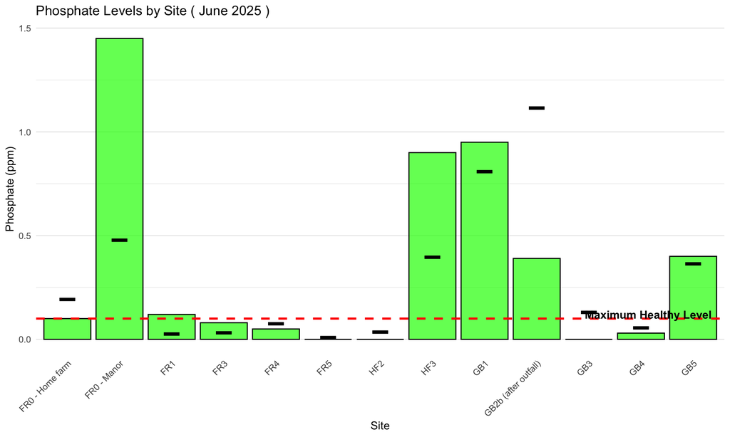

This figure shows the phosphate concentration (ppm) recorded at each monitoring site this month.

- The red dashed line marks the maximum healthy threshold. Levels above this may indicate pollution.
- The black dashed lines show the historical average for each site, helping to identify unusual spikes.

To interpret the figure:

- Values below the red line are considered within a healthy range.
- Values significantly above the black line suggest this month’s readings are unusually high compared to typical levels.

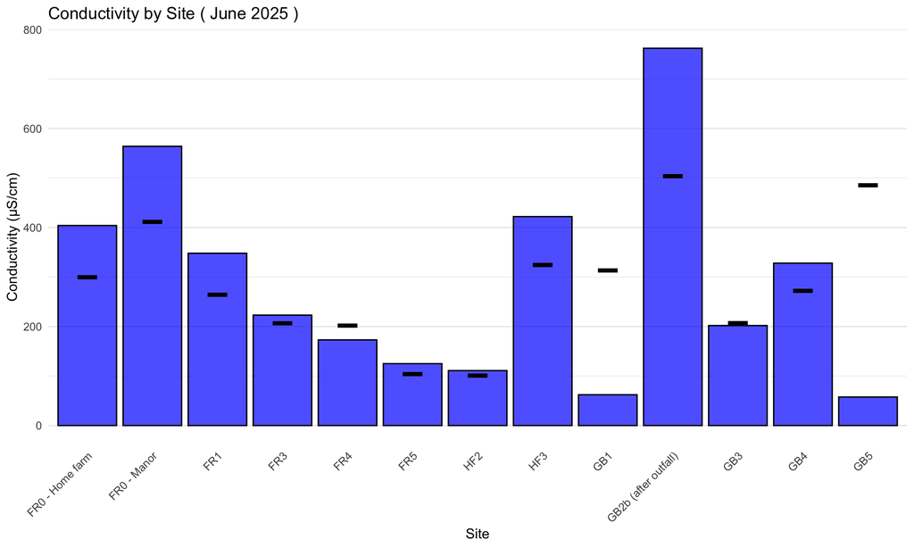

This figure shows the conductivity (μS/cm) recorded at each monitoring site this month.

- The black dashed lines show the historical average for each site.

To interpret the figure:

- Values significantly above the black line suggest this month’s readings are unusually high compared to typical levels, which might indicate a pollution event particularly if there has been a comparative spike in conductivity.

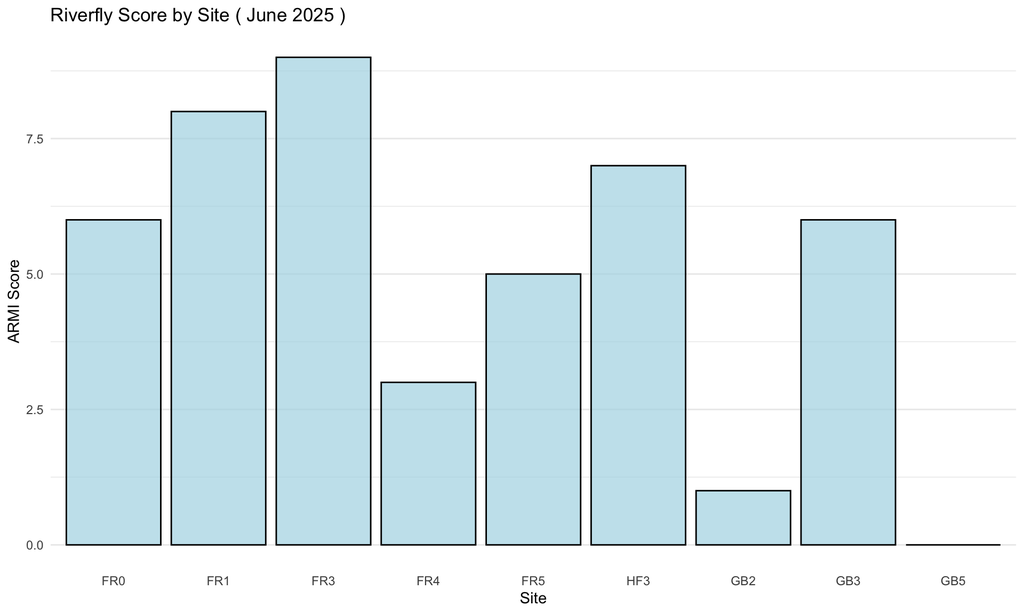

This figure shows the ARMI (Anglers’ Riverfly Monitoring Initiative) score for each site surveyed this month. The score is based on the number of freshwater invertebrates found from eight indicator groups, which vary in their tolerance to pollution. It provides a useful snapshot of ecological water quality.

Sites that are monitored regularly (at least 10 times over 12 months) are assigned a trigger level. If a site’s ARMI score falls below this threshold, it may indicate a problem. To confirm this, a follow-up survey must be carried out within 48 hours. If the schore is verified, the Environment Agency (EA) must be notified so an investigation can be launched.

For reference:

- Trigger level 3: FR5, GB3, GB5
- Trigger level 4: HF3, GB2

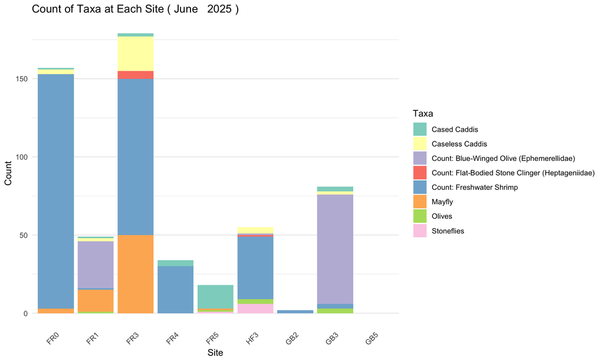

This figure shows the total number of invertebrates recorded at each monitoring site, broken down by the eight Riverfly indicator groups (or ‘taxa’). Each coloured segment in the stacked bars represents the abundance of a different group, helping us understand not just how many invertebrates were found, but which types.

These groups vary in their tolerance to pollution, so their relative abundance gives us insight into the ecological health of each site. A diverse mix with pollution-sensitive groups suggests good water quality, while dominance by tolerant groups may indicate stress or pollution.

Use this figure to:

- Compare overall invertebrate abundance across sites
- Spot shifts in community composition
- Identify sites that may need closer attention

### Water Parameters

**Conductivity** is a measure of water quality and is affected by the presence of dissolved solids such as those from sewage effluent. Conductivity naturally varies between 150 and 500 μs/cm; above this range could indicate water not suitable for certain species. A sudden change may indicate the onset of a polluting discharge.  
**Phosphate** is a common constituent of fertilisers, manure, industrial effluent, and organic wastes in sewage. In excess it can cause a reduction in dissolved oxygen in rivers, caused by excessive algal growth. Without dissolved oxygen in the water, aquatic animals cannot survive.  
**Ammonia** is an important natural resource in nature, but high levels can be toxic, causing lower reproduction and growth or death. It can be discharged into rivers from a range of sources including agricultural fertilisers and sewage effluent. It’s important to measure temperature at same time as this can impact the levels found in freshwater. Concentrations in unpolluted rivers range from 0.2 to 1.0 ppm. Tests with a reading of 3.0 ppm or above should be repeated to confirm, then reported to the EA.

### Water Quality

**Riverfly ARMI scores** are determined by collecting the animals from the river in a net following a standardised protocol, identifying 8 specific groups of animals (insect larvae and freshwater shrimp), and counting how many there are in each group. The score has been validated as a reliable measure to monitor changes in water health.